# Proses AR(2)

# Membangkitkan Model AR(2) dengan $\phi_1=0.5$ dan $\phi_2=0.2$ sebanyak 300 data

Model AR(2) yang digunakan adalah:

$$Y_t = \phi_1Y_{t-1}+\phi_2Y_{t-2}+Z_t$$

dengan:

$$Y_t=0.5Y_{t-1}+0.2Y_{t-2}+Z_t$$

dengan $Z_t\sim N(0,1)$.

## Manual

```r
# Seed agar hasil dapat direplikasi
set.seed(123)

# Parameter
n <- 300
phi1 <- 0.5
phi2 <- 0.2

# Burn-in agar pengaruh nilai awal berkurang
burn_in <- 100
N <- n + burn_in

# Bangkitkan error/residual Z_t
z <- rnorm(N)

# Menyediakan tempat untuk data AR(2)
y <- numeric(N)

# Nilai awal
y[1] <- z[1]
y[2] <- phi1 * y[1] + z[2]

# Membentuk model AR(2)
for (t in 3:N) {
  y[t] <- phi1 * y[t-1] +
    phi2 * y[t-2] +
    z[t]
}

# Ambil 300 data setelah burn-in
x_manual <- y[(burn_in + 1):N]

# Lihat 10 data pertama
head(x_manual, 10)
```

```
##  [1] -0.09430399  0.30919066 -0.11095735 -0.34118314 -1.14440161 -0.68546516
##  [7] -1.35651737 -2.48329365 -1.89317682 -0.52425053
```

## `(arima.sim)`

```r
set.seed(123)

# Bangkitkan AR(2)
x_arima <- arima.sim(
  model = list(ar = c(0.5, 0.2)),
  n = 300
)

# Lihat 10 data pertama
head(x_arima, 10)
```

```
## Time Series:
## Start = 1
## End = 10
## Frequency = 1
##  [1] -2.9518714 -1.0047928 -0.9393975 -1.8087943  0.1615383  0.1454745
##  [7] -0.1900266  0.8292073  1.2547318  1.6147884
```

# Membuat Plot Time Series, ACF, PACF dan EACF

## Plot time series

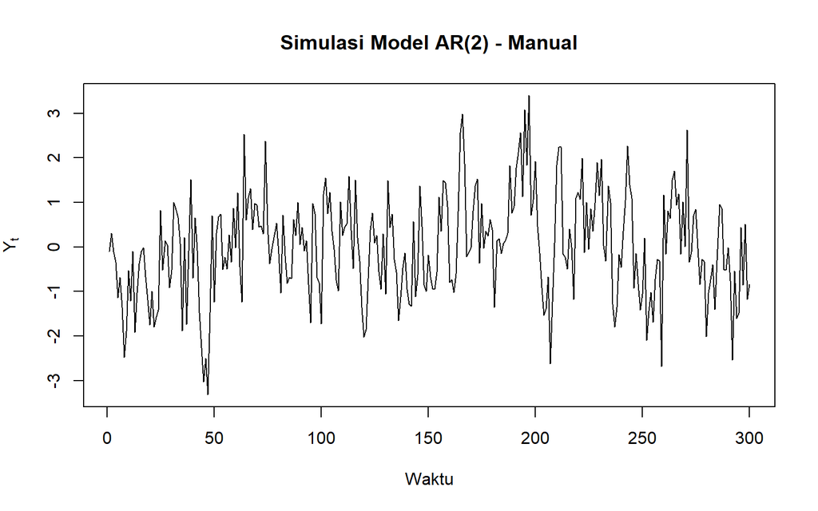

```r
plot(
  ts(x_manual),
  main = "Simulasi Model AR(2) - Manual",
  ylab = expression(Y[t]),
  xlab = "Waktu"
)
```

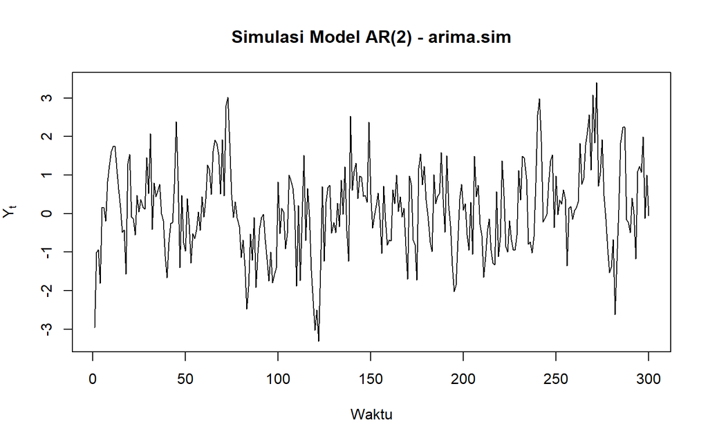

```r
plot(
  ts(x_arima),
  main = "Simulasi Model AR(2) - arima.sim",
  ylab = expression(Y[t]),
  xlab = "Waktu"
)
```

Berdasarkan plot time series Simulasi Model AR(2) - Manual dan Simulasi Model AR(2) - arima.sim, data berfluktuasi di sekitar nilai rata-rata yang relatif konstan dan tidak menunjukkan adanya tren naik atau turun yang sistematis. Penyebaran data juga relatif stabil sepanjang waktu sehingga secara visual data dapat dianggap stasioner.

## Plot ACF

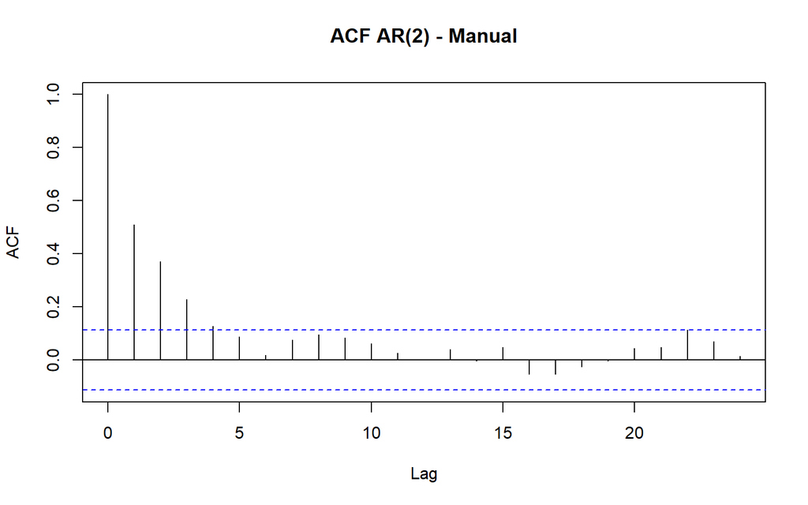

```r
acf(
  x_manual,
  main = "ACF AR(2) - Manual"
)
```

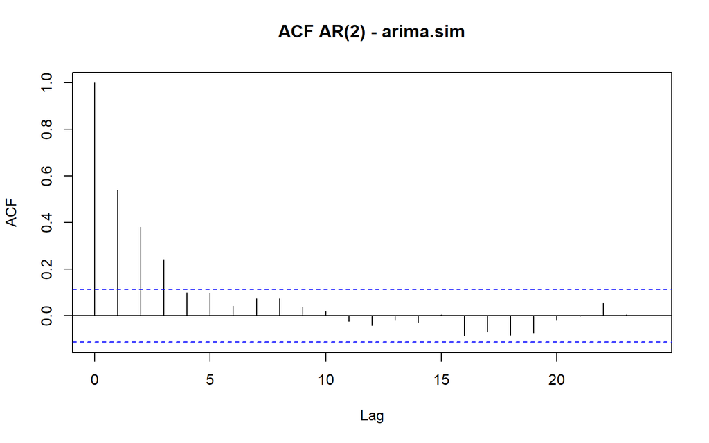

```r
acf(
  x_arima,
  main = "ACF AR(2) - arima.sim"
)
```

Pada model AR(2), nilai ACF cenderung meluruh secara bertahap (tailing off) menuju nol. Pola tersebut merupakan salah satu karakteristik model AR.

## Plot PACF

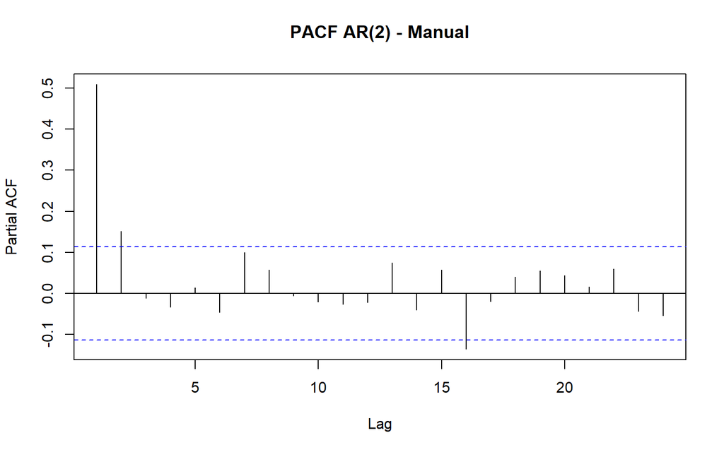

```r
pacf(
  x_manual,
  main = "PACF AR(2) - Manual"
)
```

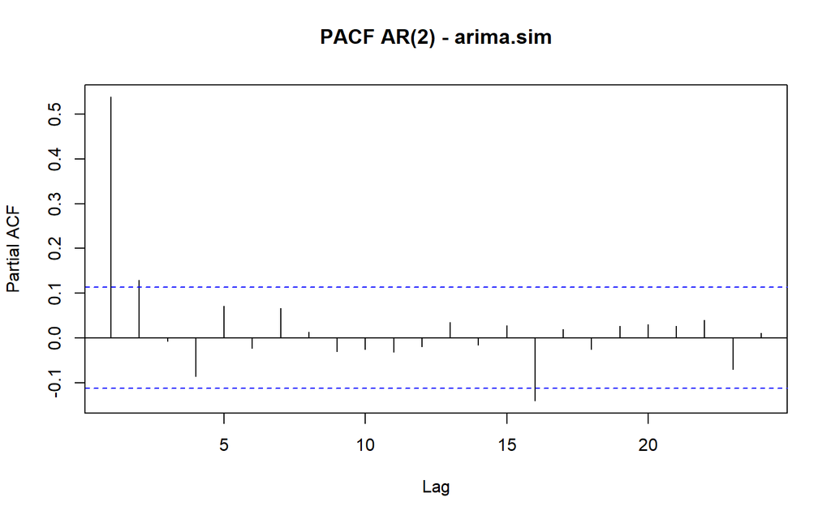

```r
pacf(
  x_arima,
  main = "PACF AR(2) - arima.sim"
)
```

Pada PACF, terdapat spike yang signifikan pada lag 1 dan lag 2, kemudian nilai PACF setelah lag 2 cenderung berada di sekitar nol. Pola cut-off setelah lag 2 merupakan karakteristik yang digunakan untuk mengidentifikasi model AR(2).

## Plot EACF

```r
# Memanggil package TSA
library(TSA)
```

```r
eacf(x_manual)
```

```
## AR/MA
##   0 1 2 3 4 5 6 7 8 9 10 11 12 13
## 0 x x x x o o o o o o o  o  o  o
## 1 x o o o o o o o o o o  o  o  o
## 2 o x o o o o o o o o o  o  o  o
## 3 x x o o o x o o o o o  o  o  o
## 4 x x o o o x o o o o o  o  o  o
## 5 x o o o o x o o o o o  o  o  o
## 6 x o x x x x o o o o o  o  o  o
## 7 x x o o o x o o o o o  o  o  o
```

```r
eacf(x_arima)
```

```
## AR/MA
##   0 1 2 3 4 5 6 7 8 9 10 11 12 13
## 0 x x x o o o o o o o o  o  o  o
## 1 x o o x o o o o o o o  o  o  o
## 2 o o o o o o o o o o o  o  o  o
## 3 o x o o o o o o o o o  o  o  o
## 4 x x o o o x o o o o o  o  o  o
## 5 x x o x o o o o o o o  o  o  o
## 6 x x o x x o o o o o o  o  o  o
## 7 x x x x x o o o o o o  o  o  o
```

Berdasarkan EACF, pola segitiga dari simbol o digunakan untuk membantu menentukan orde model ARMA. Untuk data yang dibangkitkan dari AR(2), pola EACF diharapkan menunjukkan indikasi orde AR sekitar 2 dengan orde MA mendekati 0.

# Membuat scatterplot antara 𝑌𝑡 dengan 𝑌𝑡−1, 𝑌𝑡 dengan 𝑌𝑡−2 serta 𝑌𝑡dengan 𝑌𝑡−3

## Scatterplot antara 𝑌𝑡 dengan 𝑌𝑡−1

### Manual

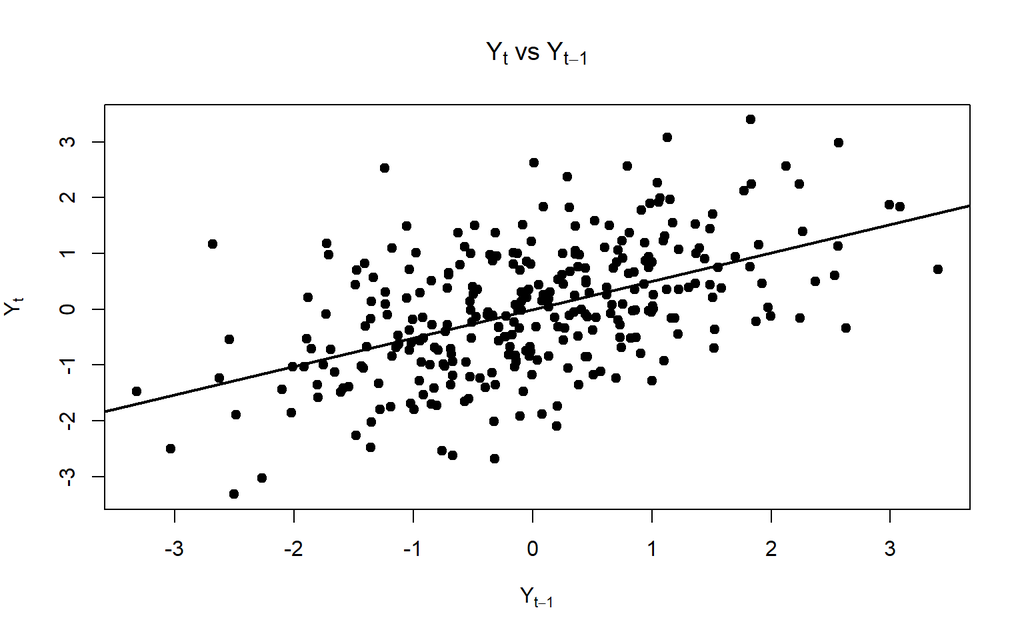

```r
plot(
  x_manual[1:(length(x_manual)-1)],
  x_manual[2:length(x_manual)],
  main = expression(Y[t] ~ "vs" ~ Y[t-1]),
  xlab = expression(Y[t-1]),
  ylab = expression(Y[t]),
  pch = 19
)

abline(
  lm(
    x_manual[2:length(x_manual)] ~
      x_manual[1:(length(x_manual)-1)]
  ),
  lwd = 2
)
```

### `(arima.sim)`

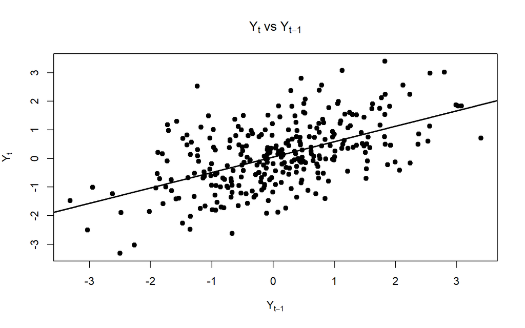

```r
plot(
  x_arima[1:(length(x_arima)-1)],
  x_arima[2:length(x_arima)],
  main = expression(Y[t] ~ "vs" ~ Y[t-1]),
  xlab = expression(Y[t-1]),
  ylab = expression(Y[t]),
  pch = 19
)

abline(
  lm(
    x_arima[2:length(x_arima)] ~
      x_arima[1:(length(x_arima)-1)]
  ),
  lwd = 2
)
```

## Scatterplot antara 𝑌𝑡 dengan 𝑌𝑡−2

### Manual

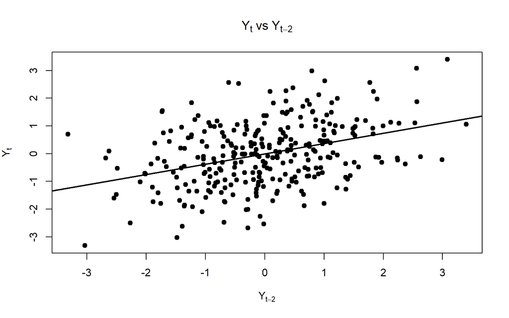

```r
plot(
  x_manual[1:(length(x_manual)-2)],
  x_manual[3:length(x_manual)],
  main = expression(Y[t] ~ "vs" ~ Y[t-2]),
  xlab = expression(Y[t-2]),
  ylab = expression(Y[t]),
  pch = 19
)

abline(
  lm(
    x_manual[3:length(x_manual)] ~
      x_manual[1:(length(x_manual)-2)]
  ),
  lwd = 2
)
```

### `(arima.sim)`

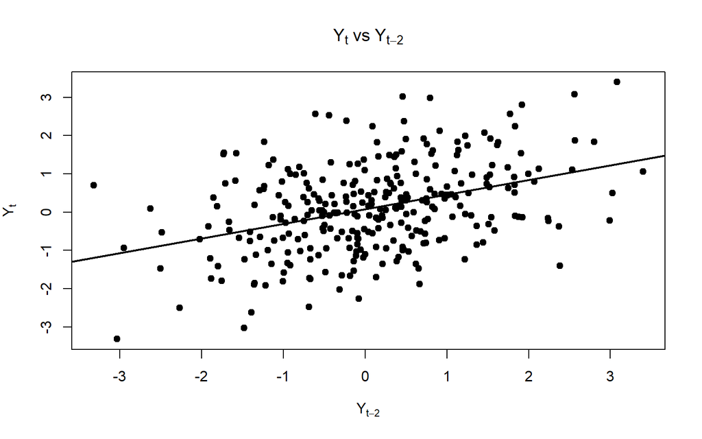

```r
plot(
  x_arima[1:(length(x_arima)-2)],
  x_arima[3:length(x_arima)],
  main = expression(Y[t] ~ "vs" ~ Y[t-2]),
  xlab = expression(Y[t-2]),
  ylab = expression(Y[t]),
  pch = 19
)

abline(
  lm(
    x_arima[3:length(x_arima)] ~
      x_arima[1:(length(x_arima)-2)]
  ),
  lwd = 2
)
```

## Scatterplot antara 𝑌𝑡 dengan 𝑌𝑡−3

### Manual

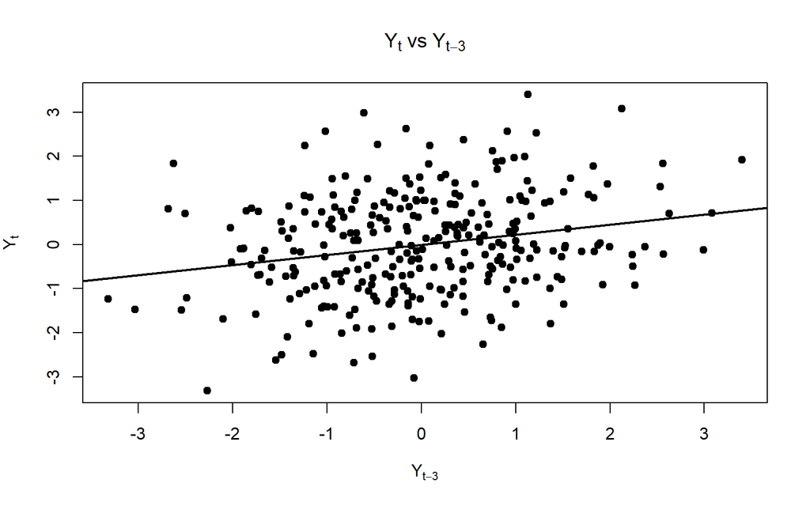

```r
plot(
  x_manual[1:(length(x_manual)-3)],
  x_manual[4:length(x_manual)],
  main = expression(Y[t] ~ "vs" ~ Y[t-3]),
  xlab = expression(Y[t-3]),
  ylab = expression(Y[t]),
  pch = 19
)

abline(
  lm(
    x_manual[4:length(x_manual)] ~
      x_manual[1:(length(x_manual)-3)]
  ),
  lwd = 2
)
```

### `(arima.sim)`

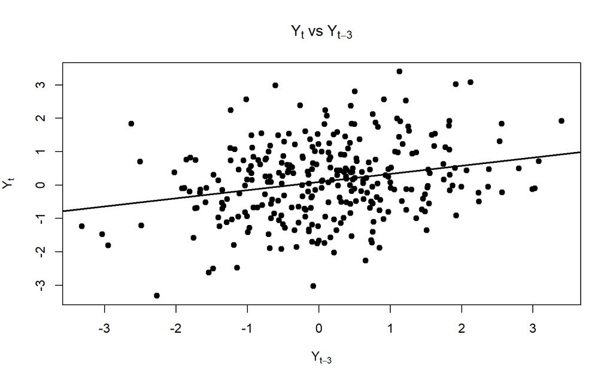

```r
plot(
  x_arima[1:(length(x_arima)-3)],
  x_arima[4:length(x_arima)],
  main = expression(Y[t] ~ "vs" ~ Y[t-3]),
  xlab = expression(Y[t-3]),
  ylab = expression(Y[t]),
  pch = 19
)

abline(
  lm(
    x_arima[4:length(x_arima)] ~
      x_arima[1:(length(x_arima)-3)]
  ),
  lwd = 2
)
```

# Mengitung autokorelasi masing masing baik dari data bangkitan maupun secara teoritis

## Autokorelasi dari data bangkitan

### Manual

```r
acf_manual <- acf(
  x_manual,
  lag.max = 10,
  plot = FALSE
)

acf_manual$acf
```

```
## , , 1
##
##             [,1]
##  [1,] 0.50868125
##  [2,] 0.37068108
##  [3,] 0.22851577
##  [4,] 0.12697332
##  [5,] 0.08637136
##  [6,] 0.01773688
##  [7,] 0.07575537
##  [8,] 0.09535729
##  [9,] 0.08404349
## [10,] 0.06239631
```

### `(arima.sim)`

```r
acf_arima <- acf(
  x_arima,
  lag.max = 10,
  plot = FALSE
)

acf_arima$acf
```

```
## , , 1
##
##             [,1]
##  [1,] 0.53836537
##  [2,] 0.38117471
##  [3,] 0.24249327
##  [4,] 0.09977753
##  [5,] 0.09715433
##  [6,] 0.04256081
##  [7,] 0.07253935
##  [8,] 0.07344132
##  [9,] 0.03757027
## [10,] 0.01850053
```

## Autokorelasi teoritis AR(2)

```r
# Parameter AR(2)
phi1 <- 0.5
phi2 <- 0.2

# Banyak lag
lag_max <- 10

# Menyediakan tempat untuk ACF teoritis
acf_theoretical <- numeric(lag_max + 1)

# rho(0)
acf_theoretical[1] <- 1

# rho(1)
acf_theoretical[2] <- phi1 / (1 - phi2)

# rho(2)
acf_theoretical[3] <- phi1 * acf_theoretical[2] + phi2

# rho(k), k >= 3
for (k in 3:lag_max) {
  acf_theoretical[k + 1] <-
    phi1 * acf_theoretical[k] +
    phi2 * acf_theoretical[k - 1]
}

acf_theoretical
```

```
##  [1] 1.00000000 0.62500000 0.51250000 0.38125000 0.29312500 0.22281250
##  [7] 0.17003125 0.12957812 0.09879531 0.07531328 0.05741570
```

## Gabungan data bangkitan dan teoritis

### Manual

```r
# ACF data bangkitan
acf_sample <- acf(
  x_manual,
  lag.max = 10,
  plot = FALSE
)

# Parameter
phi1 <- 0.5
phi2 <- 0.2

# Banyak lag
lag_max <- 10

# ACF teoritis
acf_theoretical <- numeric(lag_max + 1)

acf_theoretical[1] <- 1

acf_theoretical[2] <-
  phi1 / (1 - phi2)

acf_theoretical[3] <-
  phi1 * acf_theoretical[2] + phi2

for (k in 3:lag_max) {
  acf_theoretical[k + 1] <-
    phi1 * acf_theoretical[k] +
    phi2 * acf_theoretical[k - 1]
}

# Tabel perbandingan
acf_comparison <- data.frame(
  Lag = 1:10,
  ACF_Bangkitan = as.numeric(acf_sample$acf)[2:11],
  ACF_Teoritis = acf_theoretical[2:11]
)

acf_comparison
```

[output not shown]

### `(arima,sim)`

```r
# ACF data bangkitan
acf_sample1 <- acf(
  x_arima,
  lag.max = 10,
  plot = FALSE
)

# Parameter
phi1 <- 0.5
phi2 <- 0.2

# Banyak lag
lag_max <- 10

# ACF teoritis
acf_theoretical <- numeric(lag_max + 1)

acf_theoretical[1] <- 1

acf_theoretical[2] <-
  phi1 / (1 - phi2)

acf_theoretical[3] <-
  phi1 * acf_theoretical[2] + phi2

for (k in 3:lag_max) {
  acf_theoretical[k + 1] <-
    phi1 * acf_theoretical[k] +
    phi2 * acf_theoretical[k - 1]
}

# Tabel perbandingan
acf_comparison_sim <- data.frame(
  Lag = 1:10,
  ACF_Bangkitan = as.numeric(acf_sample1$acf)[2:11],
  ACF_Teoritis = acf_theoretical[2:11]
)

acf_comparison_sim
```

[output not shown]